# IODS course project

Matti Laukkanen

# Introduction to Open Data Science - Course Project

# About the project

I stumbled upon this course in an email that listed various phd-courses and found it useful! I did use R in one project some years ago, but I really have to refresh my memory before I get back to speed with that. Even though I don’t use R or Github currently in my phd project, I am certain that both tools will become very handy (probably essential) in the future projects.

A link to my Github Repository: https://github.com/Mattilau/IODS-project

```r
date()
```

```
## [1] "Mon Dec 11 19:49:47 2023"
```

Exercise 1 file feels definitely a practical approach to introduce oneself to R. Personally I am looking forward to more technical exercises, as I feel that the syntax is easiest to grasp when you really have to work on a specific problem. I’m curious that what is the role of the Personal Access Token? Couldn’t I upload my work to github without it?

*one minute intro for R Markdown is great!*

# Exercise 2

```r
date()
```

```
## [1] "Mon Dec 11 19:49:47 2023"
```

In this exercise, I analyze data obtained from a questionnare related to learning approaches and student achievements.The data was collected in a statistics course in Fall 2014.

I first go through the basic information about the dataset. Next, I try to find statistically significant variables that would explaine the exam points of the students. Even though in the exercise it says that you should use 3 explanatory variables, I could only find one variable that is statistically significant, which is “attitude towards statistics”. At least the result is not counter-intuitive, as it is clearly shown in the data that positive attitude towards statistics will yield more point from the exam.

I ended up using a linear regression model, and it does not look like there would be a better fit with more advanced models (polynomial for example). The students attitude towards statistics explains around 19% of the total exam points obtained. That is not very high, which implies that other factors surely affect the exam points.

```r
students2014<- read.csv("data/learning2014.csv", header = TRUE, sep = ",")
str(students2014)
```

```
## 'data.frame':    166 obs. of  7 variables:
##  $ gender  : chr  "F" "M" "F" "M" ...
##  $ Age     : int  53 55 49 53 49 38 50 37 37 42 ...
##  $ Attitude: num  3.7 3.1 2.5 3.5 3.7 3.8 3.5 2.9 3.8 2.1 ...
##  $ Points  : int  25 12 24 10 22 21 21 31 24 26 ...
##  $ deep    : num  3.58 2.92 3.5 3.5 3.67 ...
##  $ stra    : num  3.38 2.75 3.62 3.12 3.62 ...
##  $ surf    : num  2.58 3.17 2.25 2.25 2.83 ...
```

```r
dim(students2014)
```

```
## [1] 166   7
```

Our data has 166 observations for each 7 variables: Gender, age, attitude, points, deep, stra and surf. While gender and age are self-explanatory, here is some information about the rest of the variables: Attitude: General attitude towards statistics. Is a mean of 10 separate questions.

Deep: A combination variable of three question sets: 4 questions related to “seeking meaning”, 4 questions related to “relating ideas”, and 4 questions related to #use of evidence”.

Stra: A combination variable of 8 questions related to time management and organized studying, in other words “how strategic is the learning approach of the student”

Surf: A combination variable of 12 questions related to “surface approach”, i.e., how shallow is the learning approach of the student.

Points: Points for the course exam.

Let us next present some graphs of the data:

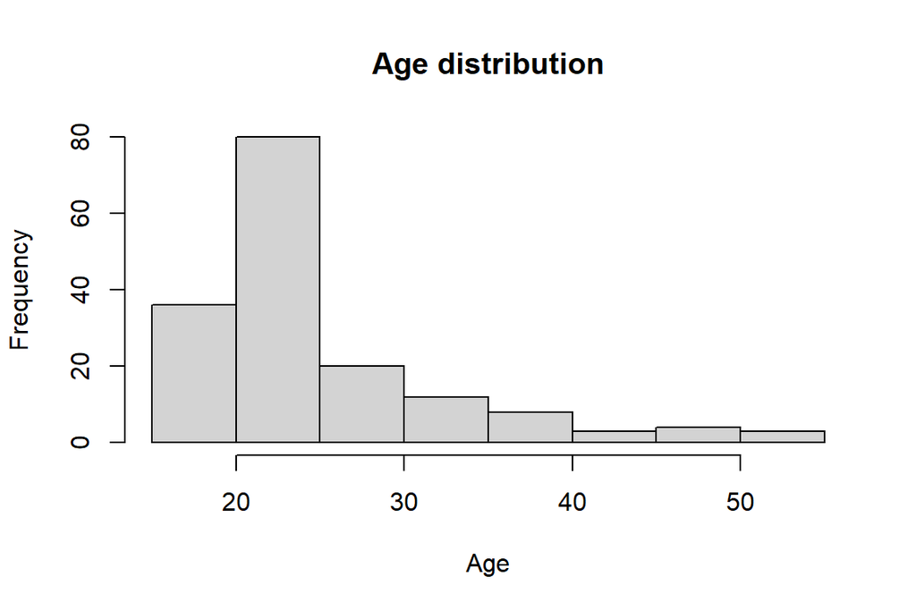

```r
hist(students2014$Age, main="Age distribution", xlab="Age")
```

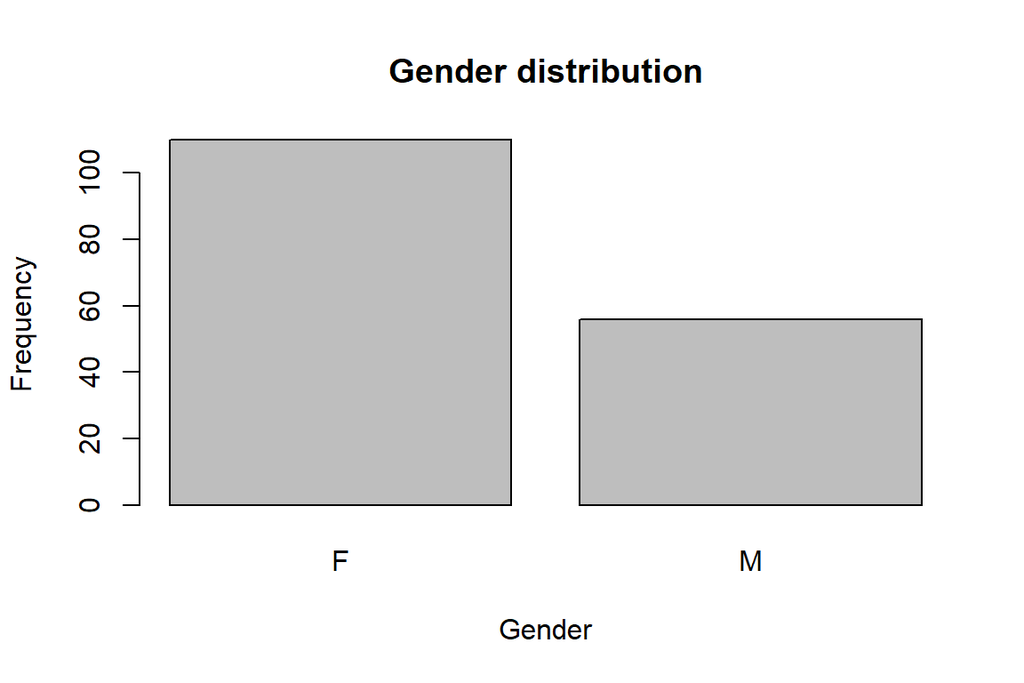

```r
barplot(table(students2014$gender), main="Gender distribution", xlab="Gender", ylab="Frequency")
```

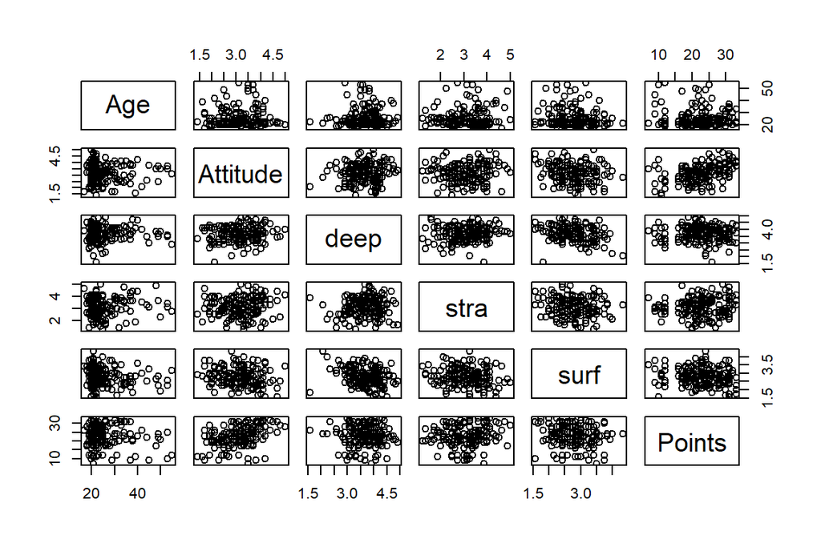

```r
pairs(students2014[, c("Age", "Attitude", "deep", "stra", "surf", "Points")])
```

As expected, our dataset consists mostly of young participants (20-30 yr), as the data was collected from an university course. The number of female respondents is considerably higher than the number of male respondents. A quick representation of all datapairs does not reveal anything significant at least at first glance. One hypothesis would be that older people would have a more strategic approach towards learning. The datapairs perhaps reveals this kind of tendency, but it should be studied further in the next sections. Also we can see a slight tendency that strategic learners got higher points from the exam than surface learners.

The summary of our data

```r
summary(students2014)
```

```
##     gender               Age           Attitude         Points
##  Length:166         Min.   :17.00   Min.   :1.400   Min.   : 7.00
##  Class :character   1st Qu.:21.00   1st Qu.:2.600   1st Qu.:19.00
##  Mode  :character   Median :22.00   Median :3.200   Median :23.00
##                     Mean   :25.51   Mean   :3.143   Mean   :22.72
##                     3rd Qu.:27.00   3rd Qu.:3.700   3rd Qu.:27.75
##                     Max.   :55.00   Max.   :5.000   Max.   :33.00
##       deep            stra            surf
##  Min.   :1.583   Min.   :1.250   Min.   :1.583
##  1st Qu.:3.333   1st Qu.:2.625   1st Qu.:2.417
##  Median :3.667   Median :3.188   Median :2.833
##  Mean   :3.680   Mean   :3.121   Mean   :2.787
##  3rd Qu.:4.083   3rd Qu.:3.625   3rd Qu.:3.167
##  Max.   :4.917   Max.   :5.000   Max.   :4.333
```

The age variation is rather large, while the median age is 22. Perhaps an interesting finding from the summary is that points for strategic learning is more spread out than the points for surface learning.

Let us next choose three variables as explanatory variables and fit a regression model where the exam points is the target variable. I hypothesize that attitude and strategic learning has statistically significant, positive effect on the exam points, while surface learning has significant negative effect.

```r
regressionpoints <- lm(Points ~ Attitude + stra + surf, data=students2014)
summary(regressionpoints)
```

```
##
## Call:
## lm(formula = Points ~ Attitude + stra + surf, data = students2014)
##
## Residuals:
##      Min       1Q   Median       3Q      Max
## -17.1550  -3.4346   0.5156   3.6401  10.8952
##
## Coefficients:
##             Estimate Std. Error t value Pr(>|t|)
## (Intercept)  11.0171     3.6837   2.991  0.00322 **
## Attitude      3.3952     0.5741   5.913 1.93e-08 ***
## stra          0.8531     0.5416   1.575  0.11716
## surf         -0.5861     0.8014  -0.731  0.46563
## ---
## Signif. codes:  0 '***' 0.001 '**' 0.01 '*' 0.05 '.' 0.1 ' ' 1
##
## Residual standard error: 5.296 on 162 degrees of freedom
## Multiple R-squared:  0.2074, Adjusted R-squared:  0.1927
## F-statistic: 14.13 on 3 and 162 DF,  p-value: 3.156e-08
```

From the explanatory variables Attitude, stra and surf, only Attitude seems statistically significant based on a linear regression model. Let us consider a scatter plot of the variables to see whether there are any linear patterns, or whether we should try polynomial regression:

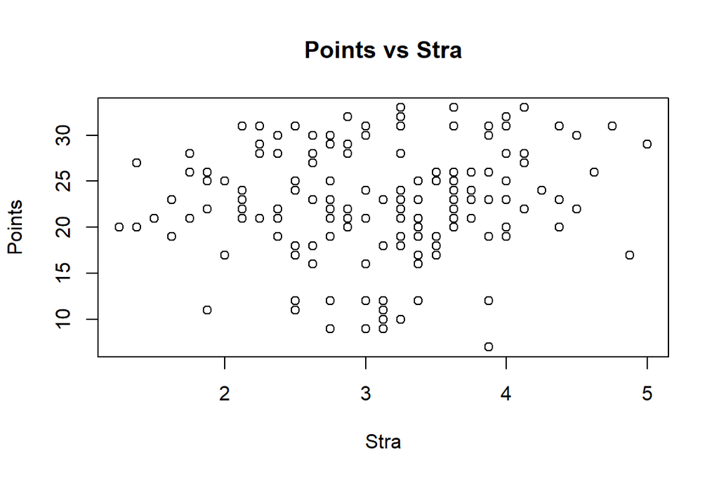

```r
plot(students2014$stra, students2014$Points, main="Points vs Stra", xlab="Stra", ylab="Points")
```

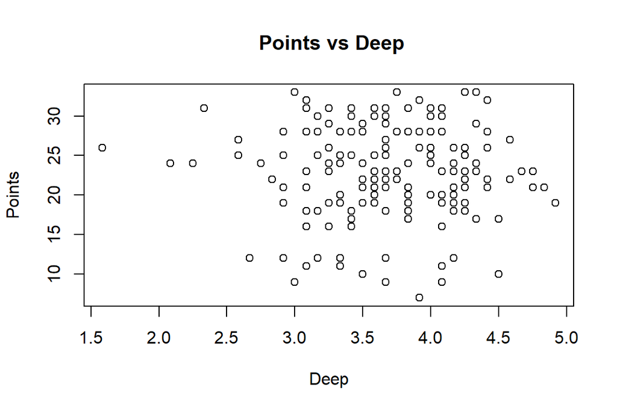

```r
plot(students2014$deep, students2014$Points, main=" Points vs Deep", xlab="Deep", ylab="Points")
```

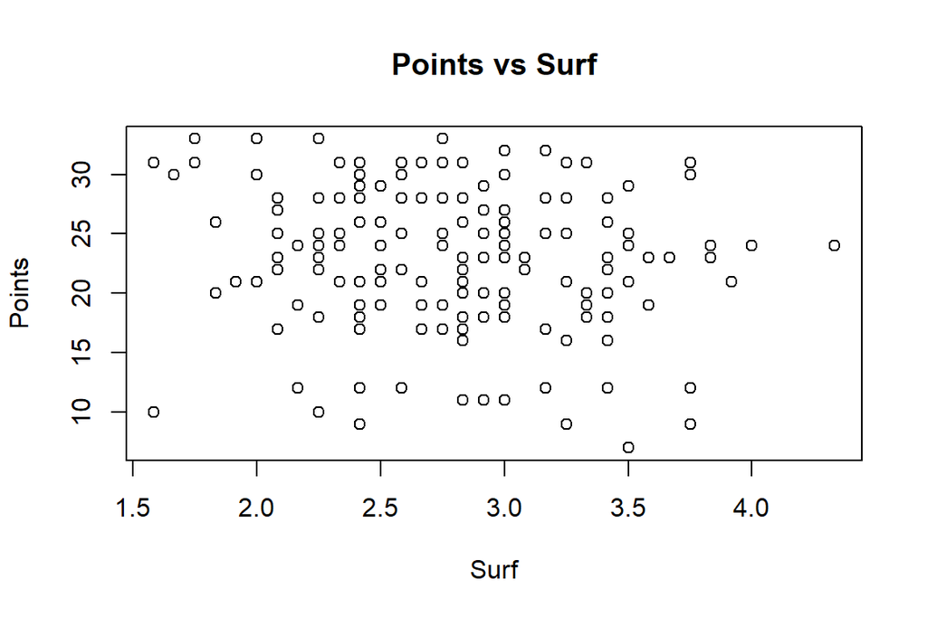

```r
plot(students2014$surf, students2014$Points, main="Points vs Surf", xlab="Surf", ylab="Points")
```

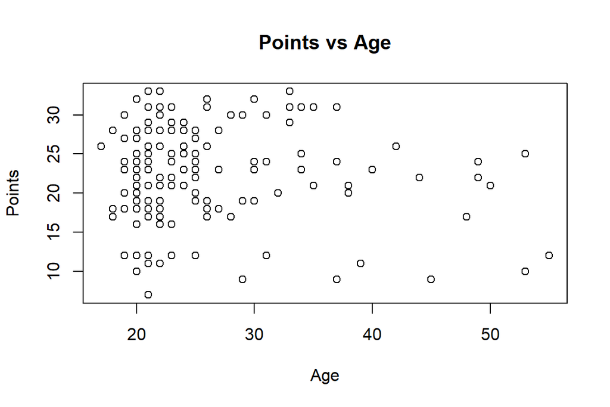

```r
plot(students2014$Age, students2014$Points, main="Points vs Age", xlab="Age", ylab="Points")
```

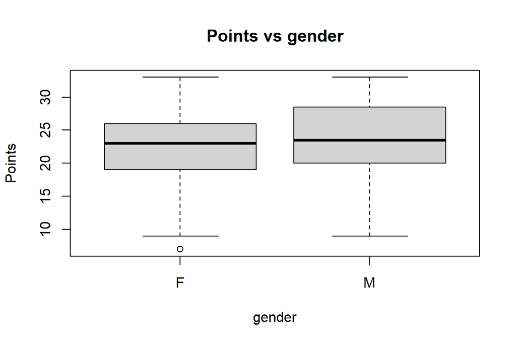

```r
boxplot(students2014$Points ~ students2014$gender, main="Points vs gender", xlab="gender", ylab="Points")
```

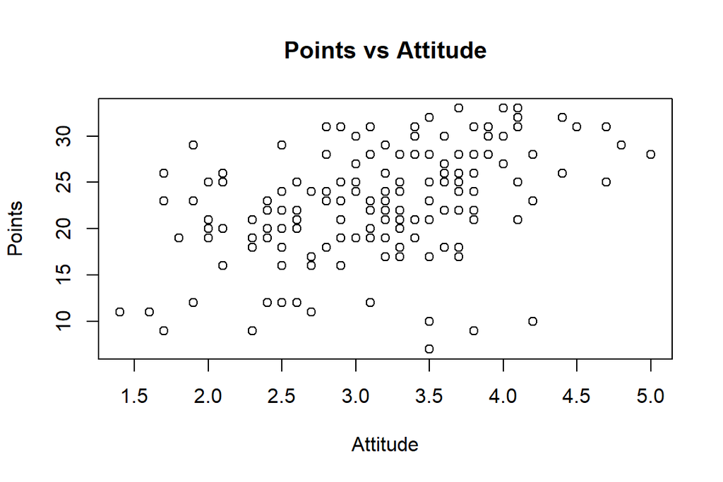

```r
plot(students2014$Attitude, students2014$Points, main="Points vs Attitude", xlab="Attitude", ylab="Points")
```

Based on graphical presentation, it really seems that Attitude is the only variable that has a linear effect on the exam points. It is also quite clear that there are no nonlinear dependencies. Let us try other variable constellations:

```r
regressionpoints <- lm(Points ~ Attitude, data=students2014)
summary(regressionpoints)
```

```
##
## Call:
## lm(formula = Points ~ Attitude, data = students2014)
##
## Residuals:
##      Min       1Q   Median       3Q      Max
## -16.9763  -3.2119   0.4339   4.1534  10.6645
##
## Coefficients:
##             Estimate Std. Error t value Pr(>|t|)
## (Intercept)  11.6372     1.8303   6.358 1.95e-09 ***
## Attitude      3.5255     0.5674   6.214 4.12e-09 ***
## ---
## Signif. codes:  0 '***' 0.001 '**' 0.01 '*' 0.05 '.' 0.1 ' ' 1
##
## Residual standard error: 5.32 on 164 degrees of freedom
## Multiple R-squared:  0.1906, Adjusted R-squared:  0.1856
## F-statistic: 38.61 on 1 and 164 DF,  p-value: 4.119e-09
```

Based on numerous iterations, it seems like the variables attitude is the only significant variable. p value is extremely small, implying the significance of the effect of Attitude. Given the estimate of attitude 3.5255, it implies that for each unit of increase in attitude, the points obtained from the exam increases by 3.5255, with a standard error 0.5674.

The multiple R-squared is 0.1906, which implies that around 19% of the variance in exam points can be explained by attitude. Adjusted R-square takes into account the number of variables and sample size, which decreases the effect of attitude to 18.5%.

Based on our results, the attitude towards statistics is a significant predictor of the exam results. However, it only explains 18.5% of the exam points. This suggests that there are definitely other factors as well that explain the variance in points.

Last, we do the diagnostic plots:

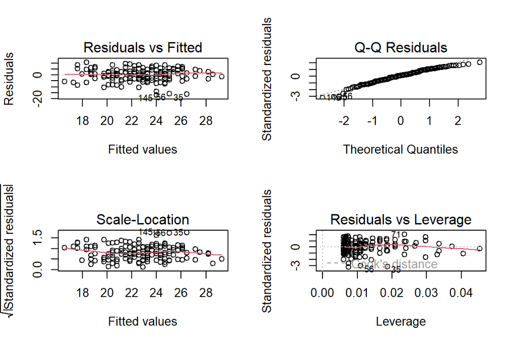

```r
par(mfrow = c(2, 2))  # Set up the graphics layout
plot(regressionpoints)  # This command will produce four plots
```

Residuals vs. fitted checks the linearity and homoscedasticity assumptions of our model. as there are no clear pattern in the scattered plots, we can conclude that the linearity and homoscedasticity assumption are valid.

In Q-Q residuals, we check the normality of residuals.As in, it tells essentially the difference between the predicted value and the actual value. In other words, the “error” in the predicted value of our model. As the data points follow closely the reference line, the assumpotion is valid.

Scale-Location is used to check the homoscedasticity, similarly as in the residuals vs. fitted. Homoscedasticity imply that the variance of the data is the same all over the data. As the residuals are spread somewhat equally, this assumption holds.

```r
# Assuming the data frame is named students2014 and you want row 71
attitude_value <- students2014[71, "Attitude"]
points_value <- students2014[71, "Points"]

# Print the values
print(paste("Attitude:", attitude_value))
```

```
## [1] "Attitude: 1.9"
```

```r
print(paste("Points:", points_value))
```

```
## [1] "Points: 29"
```

While the mean for attitude is 3.143, and mean for points is 22.72, it seems like the participant 71 has remarkably negative attitude towards statistics and still got excellent exam points. Luckily the majority of participants follow our model results, and as we know, the exception proves the rule.

# Exercise 3

```r
date()
```

```
## [1] "Mon Dec 11 19:49:50 2023"
```

In this exercise, I study data obtained from seconday education students in two Portuguese schools. The data attributes include student grades, demographic, social and school related features) and it was collected by using school reports and questionnaires. Two datasets are provided regarding the performance in two distinct subjects: Mathematics (mat) and Portuguese language (por). I have joined the two datasets into one joined set and will work with that.

Here is the dataset I use:

```r
alc_student<- read.csv("data/studentclean.csv", header = TRUE, sep = ",")
names(alc_student)
```

```
##  [1] "school"     "sex"        "age"        "address"    "famsize"
##  [6] "Pstatus"    "Medu"       "Fedu"       "Mjob"       "Fjob"
## [11] "reason"     "guardian"   "traveltime" "studytime"  "schoolsup"
## [16] "famsup"     "activities" "nursery"    "higher"     "internet"
## [21] "romantic"   "famrel"     "freetime"   "goout"      "Dalc"
## [26] "Walc"       "health"     "alc_use"    "high_use"
```

**Explanations for the variables:** 1 school - student’s school (binary: ‘GP’ - Gabriel Pereira or ‘MS’ - Mousinho da Silveira) 2 sex - student’s sex (binary: ‘F’ - female or ‘M’ - male) 3 age - student’s age (numeric: from 15 to 22) 4 address - student’s home address type (binary: ‘U’ - urban or ‘R’ - rural) 5 famsize - family size (binary: ‘LE3’ - less or equal to 3 or ‘GT3’ - greater than 3) 6 Pstatus - parent’s cohabitation status (binary: ‘T’ - living together or ‘A’ - apart) 7 Medu - mother’s education (numeric: 0 - none, 1 - primary education (4th grade), 2 – 5th to 9th grade, 3 – secondary education or 4 – higher education) 8 Fedu - father’s education (numeric: 0 - none, 1 - primary education (4th grade), 2 – 5th to 9th grade, 3 – secondary education or 4 – higher education) 9 Mjob - mother’s job (nominal: ‘teacher’, ‘health’ care related, civil ‘services’ (e.g. administrative or police), ‘at_home’ or ‘other’) 10 Fjob - father’s job (nominal: ‘teacher’, ‘health’ care related, civil ‘services’ (e.g. administrative or police), ‘at_home’ or ‘other’) 11 reason - reason to choose this school (nominal: close to ‘home’, school ‘reputation’, ‘course’ preference or ‘other’) 12 guardian - student’s guardian (nominal: ‘mother’, ‘father’ or ‘other’) 13 traveltime - home to school travel time (numeric: 1 - <15 min., 2 - 15 to 30 min., 3 - 30 min. to 1 hour, or 4 - >1 hour) 14 studytime - weekly study time (numeric: 1 - <2 hours, 2 - 2 to 5 hours, 3 - 5 to 10 hours, or 4 - >10 hours) 16 schoolsup - extra educational support (binary: yes or no) 17 famsup - family educational support (binary: yes or no) 19 activities - extra-curricular activities (binary: yes or no) 20 nursery - attended nursery school (binary: yes or no) 21 higher - wants to take higher education (binary: yes or no) 22 internet - Internet access at home (binary: yes or no) 23 romantic - with a romantic relationship (binary: yes or no) 24 famrel - quality of family relationships (numeric: from 1 - very bad to 5 - excellent) 25 freetime - free time after school (numeric: from 1 - very low to 5 - very high) 26 goout - going out with friends (numeric: from 1 - very low to 5 - very high) 27 Dalc - workday alcohol consumption (numeric: from 1 - very low to 5 - very high) 28 Walc - weekend alcohol consumption (numeric: from 1 - very low to 5 - very high) 29 health - current health status (numeric: from 1 - very bad to 5 - very good) alc_use - average from Dalc and Walc High_use TRUE if average alc_use is above 2

Next, I will choose 4 interesting variables that could have aconnection with the student alcohol consumption. I assume that if the student is not in a romantic relationship (romantic = no), they use more alcohol, as they go out more often and are more eager to meet new people. Further, I assume that going out of with friends (goout) as a highly positive correlation with alcohol consumption. I hypothesize that fathers education (Fedu) has a negative correlation with the alcohol usage, although this is bit of a strecth. Interesting to see the results. Weekly studytime (studytime) definitely has a negative correlation with alcohol usage.

**Let us first study graphically whether my hypotheses are correct:**

```r
# Summary of alc_use
summary(alc_student$alc_use)
```

```
##    Min. 1st Qu.  Median    Mean 3rd Qu.    Max.
##   1.000   1.000   1.500   1.889   2.500   5.000
```

```r
summary(alc_student$high_use)
```

```
##    Mode   FALSE    TRUE
## logical     259     111
```

```r
# Cross-tabulation for each categorical variable with alc_use
table(alc_student$romantic, alc_student$alc_use)
```

```
##
##        1 1.5  2 2.5  3 3.5  4 4.5  5
##   no  98  42 33  29 25  13  6   1  4
##   yes 42  21 23  12  7   4  3   2  5
```

```r
table(alc_student$goout, alc_student$alc_use)
```

```
##
##      1 1.5  2 2.5  3 3.5  4 4.5  5
##   1 14   3  2   2  0   1  0   0  0
##   2 49  20 13   7  4   2  0   1  1
##   3 44  28 25  13  3   4  1   0  2
##   4 24   7  9  15 14   3  5   1  0
##   5  9   5  7   4 11   7  3   1  6
```

```r
table(alc_student$Fedu, alc_student$alc_use)
```

```
##
##      1 1.5  2 2.5  3 3.5  4 4.5  5
##   0  2   0  0   0  0   0  0   0  0
##   1 25  15  9   7  8   5  1   1  2
##   2 42  15 18   9 10   5  1   1  4
##   3 37  18 15  13  8   1  5   0  0
##   4 34  15 14  12  6   6  2   1  3
```

```r
table(alc_student$studytime, alc_student$alc_use)
```

```
##
##      1 1.5  2 2.5  3 3.5  4 4.5  5
##   1 21  18 17  10 12  11  4   0  5
##   2 72  31 25  25 18   4  4   3  3
##   3 30  10 12   5  1   2  0   0  0
##   4 17   4  2   1  1   0  1   0  1
```

Out of 370 observations, we have 111 high alcohol users. The median for alcohol consumption is 1.5/day, which imply that the vast majority is in low alcohol consumption group.

**Let us try bar plots:**

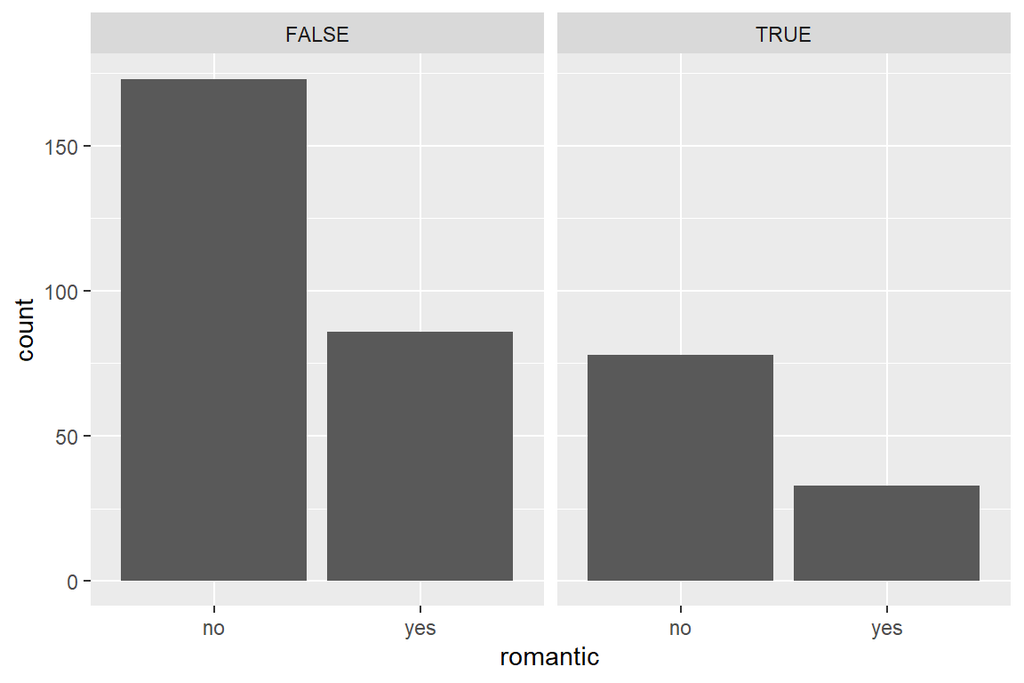

```r
library(ggplot2)

# Bar plot for each categorical variable against alc_use
ggplot(alc_student, aes(x = romantic)) +
  geom_bar() +
  facet_wrap(~high_use)
```

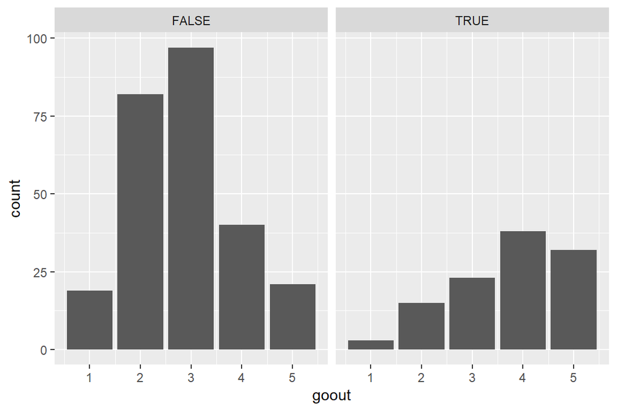

```r
ggplot(alc_student, aes(x = goout)) +
  geom_bar() +
  facet_wrap(~high_use)
```

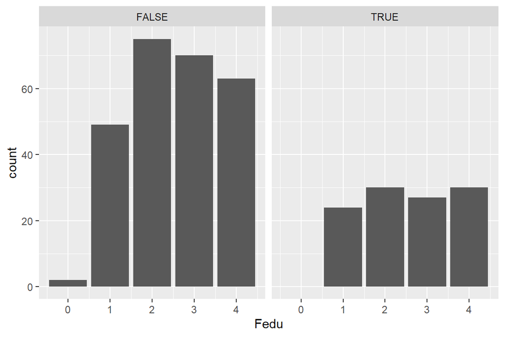

```r
ggplot(alc_student, aes(x = Fedu)) +
  geom_bar() +
  facet_wrap(~high_use)
```

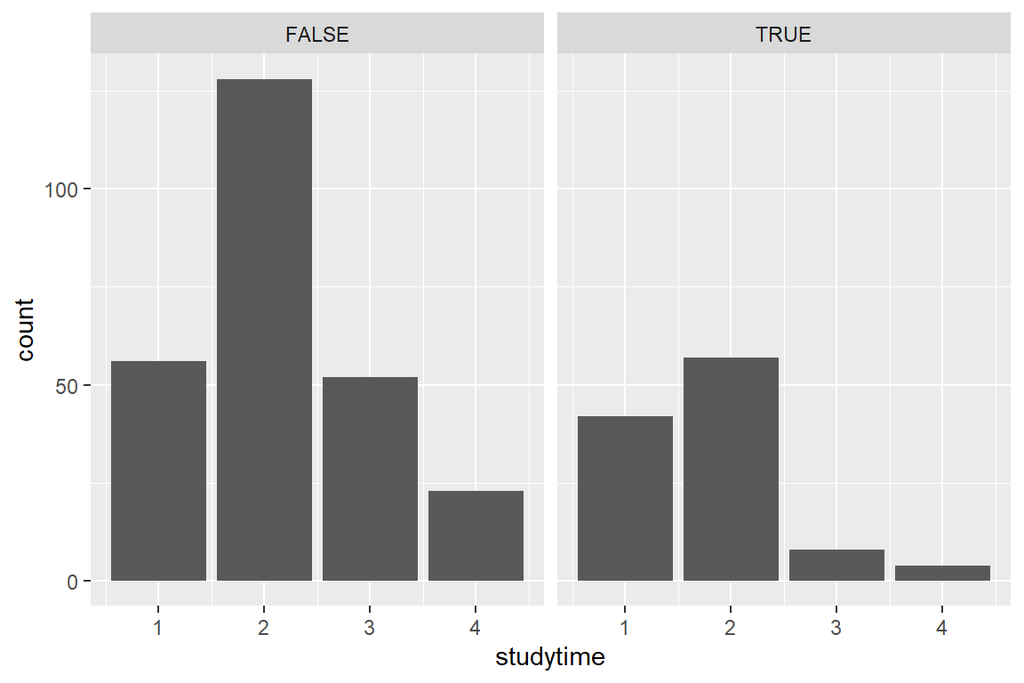

```r
ggplot(alc_student, aes(x = studytime)) +
  geom_bar() +
  facet_wrap(~high_use)
```

**Let us next continue the analysis by logistic regression using a generalized linear model:**

```r
# Logistic regression model
logistic_model <- glm(high_use ~ romantic + goout + Fedu + studytime,
                      data = alc_student,
                      family = "binomial")
# Model summary
summary(logistic_model)
```

```
##
## Call:
## glm(formula = high_use ~ romantic + goout + Fedu + studytime,
##     family = "binomial", data = alc_student)
##
## Coefficients:
##              Estimate Std. Error z value Pr(>|z|)
## (Intercept) -2.056775   0.584141  -3.521 0.000430 ***
## romanticyes -0.149987   0.269226  -0.557 0.577457
## goout        0.744130   0.117627   6.326 2.51e-10 ***
## Fedu         0.007955   0.114804   0.069 0.944756
## studytime   -0.616809   0.166221  -3.711 0.000207 ***
## ---
## Signif. codes:  0 '***' 0.001 '**' 0.01 '*' 0.05 '.' 0.1 ' ' 1
##
## (Dispersion parameter for binomial family taken to be 1)
##
##     Null deviance: 452.04  on 369  degrees of freedom
## Residual deviance: 387.09  on 365  degrees of freedom
## AIC: 397.09
##
## Number of Fisher Scoring iterations: 4
```

I use the generalized linear model (GLM), which should be more suitable when the dependent variable is binary. It seems like studytime and goout are statistically significant, where goout has a positive correlation with high alcohol use and studytime has a negative correlation. Both effects are in line with my original hypotheses. Relationship and fathers education does not have any statistical significance.

Next, we **present and interpret the coefficients of the model as odds ratios and provide confidence intervals for them.**

```r
# Exponentiate the coefficients to get odds ratios
odds_ratios <- exp(coef(logistic_model))
print(odds_ratios)
```

```
## (Intercept) romanticyes       goout        Fedu   studytime
##   0.1278656   0.8607194   2.1046102   1.0079869   0.5396638
```

```r
# Calculate and exponentiate confidence intervals
conf_int <- exp(confint(logistic_model))
print(conf_int)
```

```
##                 2.5 %    97.5 %
## (Intercept) 0.0395803 0.3931552
## romanticyes 0.5039707 1.4519188
## goout       1.6814512 2.6692486
## Fedu        0.8047044 1.2633483
## studytime   0.3850972 0.7403200
```

The odds ratio greater than 1 indicates that the predictor increases the odds of being an high alcohol user. The results show that the ‘goout’ variable increases the odds of TRUE answer in high_use, while ‘studytime’ decreases the odds of TRUE answer. Similarly, ‘Fedu’ would increase and ‘romantic ->yes’ would decrease the odds of being a high alcohol user, but their condifence intervals range below and above one, implying that the effect is not clear. For ‘goout’ and ‘studytime’, the confidence intervals imply that there is a 95% change that the variables increase/decrease the odds of high alcohol use.

```r
# Predict probabilities
predicted_probs <- predict(logistic_model, type = "response")

# Classify as TRUE or FALSE based on a 0.5 cutoff
predicted_class <- ifelse(predicted_probs > 0.5, TRUE, FALSE)

alc_student$predicted_high_use <- predicted_class

# 2x2 Cross Tabulation
table(Actual = alc_student$high_use, Predicted = alc_student$predicted_high_use)
```

```
##        Predicted
## Actual  FALSE TRUE
##   FALSE   238   21
##   TRUE     70   41
```

```r
# Training error
training_error <- mean(alc_student$high_use != alc_student$predicted_high_use)
print(training_error)
```

```
## [1] 0.2459459
```

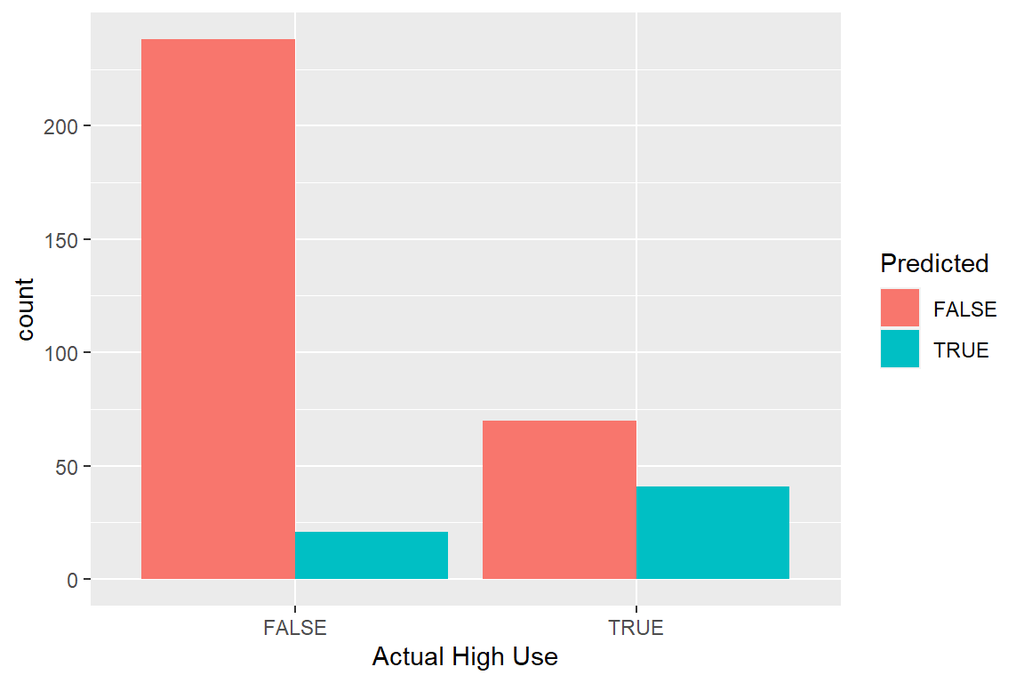

```r
library(ggplot2)

ggplot(alc_student, aes(x = high_use, fill = as.factor(predicted_high_use))) +
  geom_bar(position = "dodge") +
  labs(x = "Actual High Use", fill = "Predicted")
```

So, from 259 FALSE answers, my model was able to predict 238 correctly, while it incorrectly predicted 21 of them as TRUE. From 111 TRUE answers, it got 41 correct and predicted 70 as false.

Let us compare our results with a simple guessing strategy:

```r
# Simple guessing strategy: classify all as the most frequent class
most_frequent_class <- ifelse(mean(alc_student$high_use) > 0.5, TRUE, FALSE)
simple_guess_accuracy <- mean(alc_student$high_use == most_frequent_class)

# Compare
model_accuracy <- 1 - training_error
print(c("Model Accuracy" = model_accuracy, "Simple Guess Accuracy" = simple_guess_accuracy))
```

```
##        Model Accuracy Simple Guess Accuracy
##             0.7540541             0.7000000
```

The accuracy of my model is ~0.754 and a simple guessing strategy gives 0.7 accuracy. This is not a very convincing result, and I must admit that my model is not very accurate in predicting the outcome.

**BONUS:** Let us next perform a 10-fold cross-validation on our model.

```r
library(caret)
set.seed(123) # for reproducibility
train_control <- trainControl(method = "cv", number = 10)

# Convert 'high_use' from logical to factor
alc_student$high_use <- as.factor(alc_student$high_use)

# Now, run the 10-fold cross-validation
model_cv <- train(high_use ~ goout + studytime,
                  data = alc_student,
                  method = "glm",
                  family = "binomial",
                  trControl = train_control)

# Look at the results
print(model_cv)
```

```
## Generalized Linear Model
##
## 370 samples
##   2 predictor
##   2 classes: 'FALSE', 'TRUE'
##
## No pre-processing
## Resampling: Cross-Validated (10 fold)
## Summary of sample sizes: 333, 333, 333, 333, 333, 333, ...
## Resampling results:
##
##   Accuracy   Kappa
##   0.7543188  0.3283833
```

The Kappa statistic (or Cohen’s Kappa) is a measure of the agreement between the predicted and actual classifications, corrected for the agreement that could occur by chance. My results 0.328 imply that the model result is better at predicting the ‘high_use’ status than a random chance.

# Exercise 4

```r
date()
```

```
## [1] "Mon Dec 11 19:49:55 2023"
```

First, I need to load the “Boston” data from the MASS package: (And apparently I have to excplicitly set the CRAN mirror, otherwise knitting does not work)

```r
options(repos = c(CRAN = "https://cran.rstudio.com"))
install.packages("MASS")
library(MASS)
```

Loading the Boston dataset and exploring the structure:

```r
data(Boston)
str (Boston)
```

```
## 'data.frame':    506 obs. of  14 variables:
##  $ crim   : num  0.00632 0.02731 0.02729 0.03237 0.06905 ...
##  $ zn     : num  18 0 0 0 0 0 12.5 12.5 12.5 12.5 ...
##  $ indus  : num  2.31 7.07 7.07 2.18 2.18 2.18 7.87 7.87 7.87 7.87 ...
##  $ chas   : int  0 0 0 0 0 0 0 0 0 0 ...
##  $ nox    : num  0.538 0.469 0.469 0.458 0.458 0.458 0.524 0.524 0.524 0.524 ...
##  $ rm     : num  6.58 6.42 7.18 7 7.15 ...
##  $ age    : num  65.2 78.9 61.1 45.8 54.2 58.7 66.6 96.1 100 85.9 ...
##  $ dis    : num  4.09 4.97 4.97 6.06 6.06 ...
##  $ rad    : int  1 2 2 3 3 3 5 5 5 5 ...
##  $ tax    : num  296 242 242 222 222 222 311 311 311 311 ...
##  $ ptratio: num  15.3 17.8 17.8 18.7 18.7 18.7 15.2 15.2 15.2 15.2 ...
##  $ black  : num  397 397 393 395 397 ...
##  $ lstat  : num  4.98 9.14 4.03 2.94 5.33 ...
##  $ medv   : num  24 21.6 34.7 33.4 36.2 28.7 22.9 27.1 16.5 18.9 ...
```

```r
dim(Boston)
```

```
## [1] 506  14
```

The Boston dataset shows the housing values in different suburbs of Boston. The dataframe has a total of 506 observations of 14 variables. I explain the variables below: crim: per capita crime rate by town zn: proportion of residential land zoned for lots over 25,000 sq.ft. indus: proportion of non-retail business acres per town. chas: Charles River dummy variable (= 1 if tract bounds river; 0 otherwise). nox: nitrogen oxides concentration (parts per 10 million). rm: average number of rooms per dwelling. age: proportion of owner-occupied units built prior to 1940. dis: weighted mean of distances to five Boston employment centres. rad: index of accessibility to radial highways. tax: full-value property-tax rate per $10,000. ptratio: pupil-teacher ratio by town. black: the proporotion of blacks by town lstat: lower status of the population (percent). medv: median value of owner-occupied homes in $1000s.

**Next, let us examine the data and try to figure out what is going on here:**

```r
summary(Boston)
```

```
##       crim                zn             indus            chas
##  Min.   : 0.00632   Min.   :  0.00   Min.   : 0.46   Min.   :0.00000
##  1st Qu.: 0.08205   1st Qu.:  0.00   1st Qu.: 5.19   1st Qu.:0.00000
##  Median : 0.25651   Median :  0.00   Median : 9.69   Median :0.00000
##  Mean   : 3.61352   Mean   : 11.36   Mean   :11.14   Mean   :0.06917
##  3rd Qu.: 3.67708   3rd Qu.: 12.50   3rd Qu.:18.10   3rd Qu.:0.00000
##  Max.   :88.97620   Max.   :100.00   Max.   :27.74   Max.   :1.00000
##       nox               rm             age              dis
##  Min.   :0.3850   Min.   :3.561   Min.   :  2.90   Min.   : 1.130
##  1st Qu.:0.4490   1st Qu.:5.886   1st Qu.: 45.02   1st Qu.: 2.100
##  Median :0.5380   Median :6.208   Median : 77.50   Median : 3.207
##  Mean   :0.5547   Mean   :6.285   Mean   : 68.57   Mean   : 3.795
##  3rd Qu.:0.6240   3rd Qu.:6.623   3rd Qu.: 94.08   3rd Qu.: 5.188
##  Max.   :0.8710   Max.   :8.780   Max.   :100.00   Max.   :12.127
##       rad              tax           ptratio          black
##  Min.   : 1.000   Min.   :187.0   Min.   :12.60   Min.   :  0.32
##  1st Qu.: 4.000   1st Qu.:279.0   1st Qu.:17.40   1st Qu.:375.38
##  Median : 5.000   Median :330.0   Median :19.05   Median :391.44
##  Mean   : 9.549   Mean   :408.2   Mean   :18.46   Mean   :356.67
##  3rd Qu.:24.000   3rd Qu.:666.0   3rd Qu.:20.20   3rd Qu.:396.23
##  Max.   :24.000   Max.   :711.0   Max.   :22.00   Max.   :396.90
##      lstat            medv
##  Min.   : 1.73   Min.   : 5.00
##  1st Qu.: 6.95   1st Qu.:17.02
##  Median :11.36   Median :21.20
##  Mean   :12.65   Mean   :22.53
##  3rd Qu.:16.95   3rd Qu.:25.00
##  Max.   :37.97   Max.   :50.00
```

Here we have all the observations of all variables summarized. The median crime rate seems to be very low compare to the max (0.25 vs. 88.9), which implies that there is some suburbs with extremely large crime rate compared to the rest. It is important to note that the “chas” is a dummy variable that is either 1 if the tract is next to the Charles River and 0 otherwise. The median value of homes has also a large variance, which is of course expected.

**Let us next visualize the data graphically:**

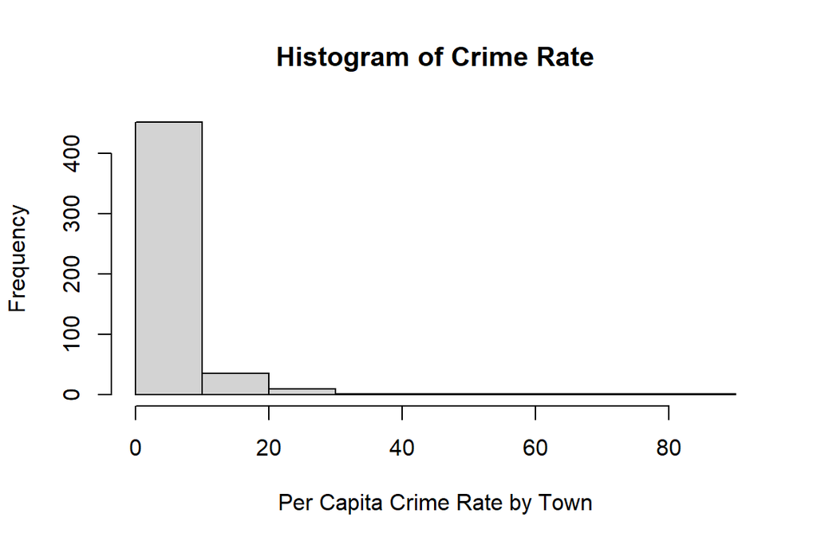

```r
# Histogram for per capita crime rate by town
hist(Boston$crim, main="Histogram of Crime Rate", xlab="Per Capita Crime Rate by Town")
```

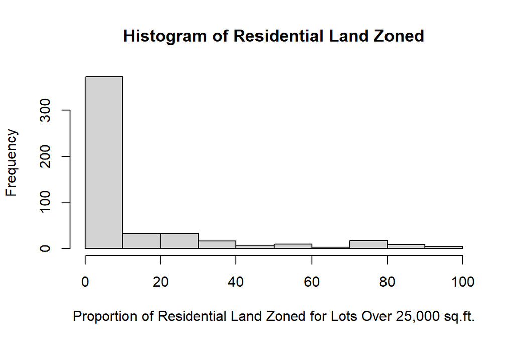

```r
# Histogram for proportion of residential land zoned for lots over 25,000 sq.ft.
hist(Boston$zn, main="Histogram of Residential Land Zoned", xlab="Proportion of Residential Land Zoned for Lots Over 25,000 sq.ft.")
```

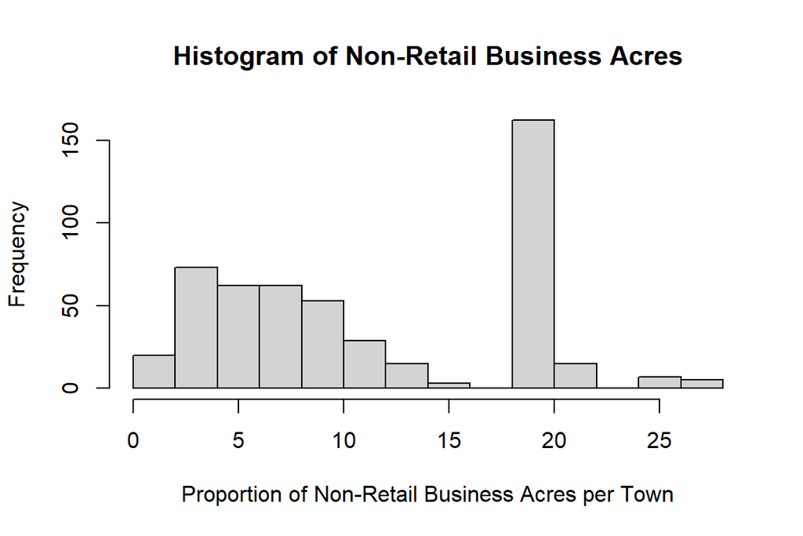

```r
# Histogram for proportion of non-retail business acres per town
hist(Boston$indus, main="Histogram of Non-Retail Business Acres", xlab="Proportion of Non-Retail Business Acres per Town")
```

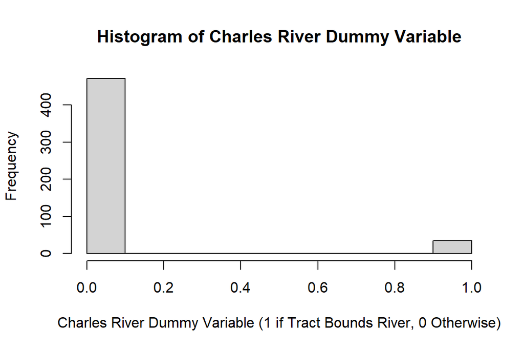

```r
# Histogram for Charles River dummy variable
hist(Boston$chas, main="Histogram of Charles River Dummy Variable", xlab="Charles River Dummy Variable (1 if Tract Bounds River, 0 Otherwise)")
```

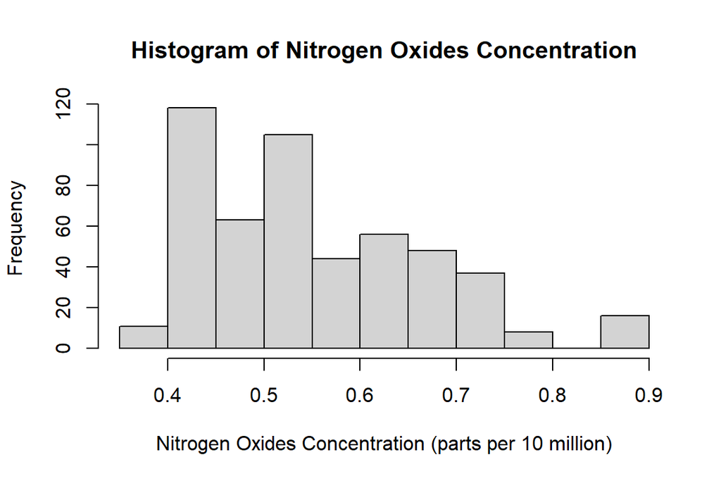

```r
# Histogram for nitrogen oxides concentration
hist(Boston$nox, main="Histogram of Nitrogen Oxides Concentration", xlab="Nitrogen Oxides Concentration (parts per 10 million)")
```

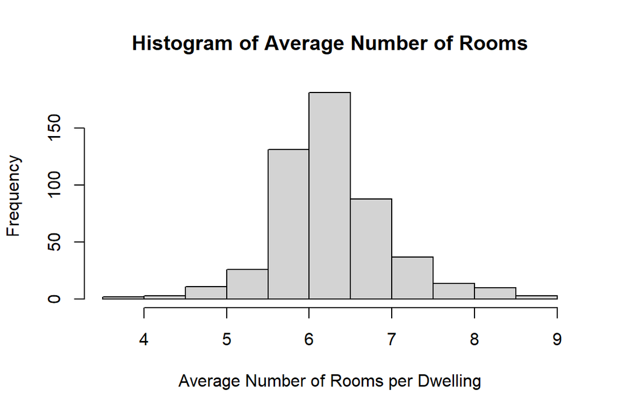

```r
# Histogram for average number of rooms per dwelling
hist(Boston$rm, main="Histogram of Average Number of Rooms", xlab="Average Number of Rooms per Dwelling")
```

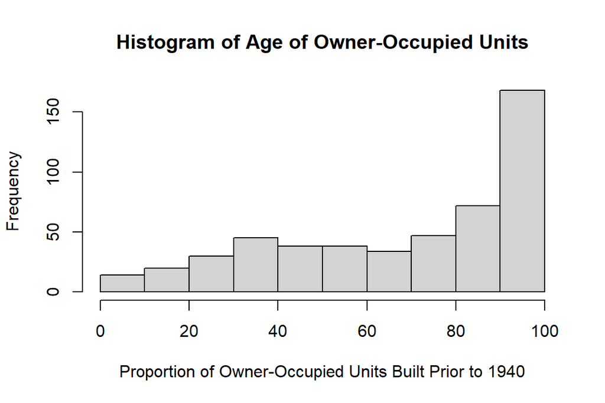

```r
# Histogram for proportion of owner-occupied units built prior to 1940
hist(Boston$age, main="Histogram of Age of Owner-Occupied Units", xlab="Proportion of Owner-Occupied Units Built Prior to 1940")
```

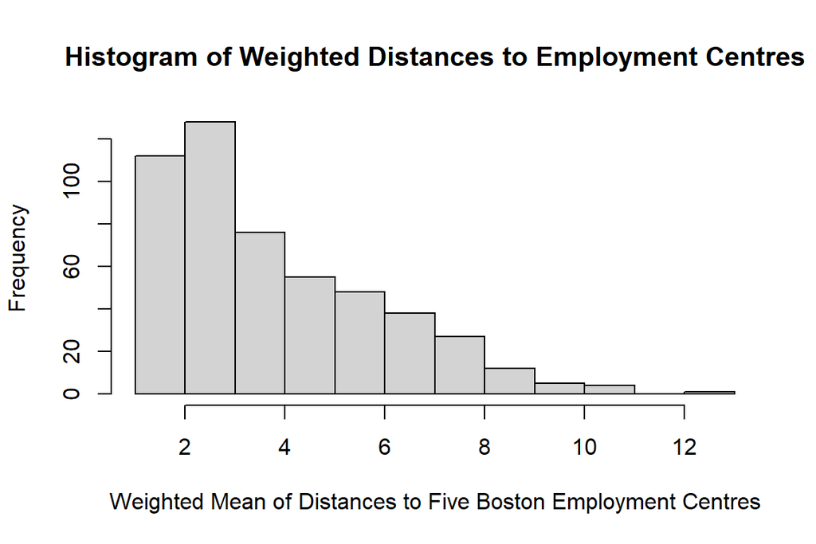

```r
# Histogram for weighted mean of distances to five Boston employment centres
hist(Boston$dis, main="Histogram of Weighted Distances to Employment Centres", xlab="Weighted Mean of Distances to Five Boston Employment Centres")
```

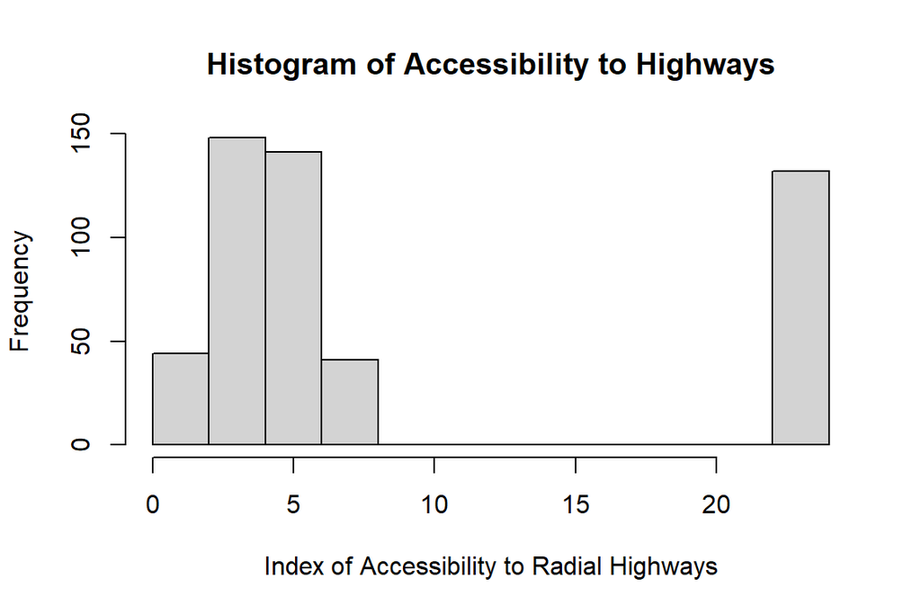

```r
# Histogram for index of accessibility to radial highways
hist(Boston$rad, main="Histogram of Accessibility to Highways", xlab="Index of Accessibility to Radial Highways")
```

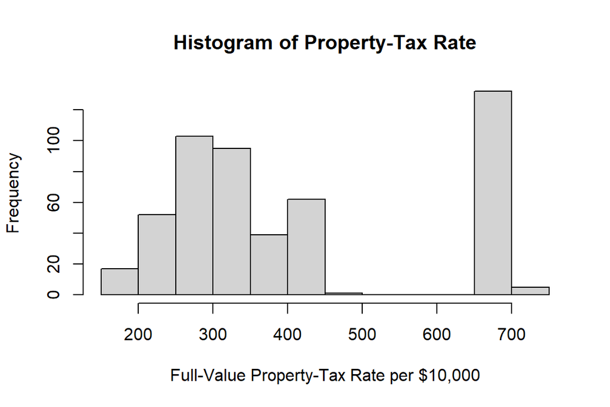

```r
# Histogram for full-value property-tax rate per $10,000
hist(Boston$tax, main="Histogram of Property-Tax Rate", xlab="Full-Value Property-Tax Rate per $10,000")
```

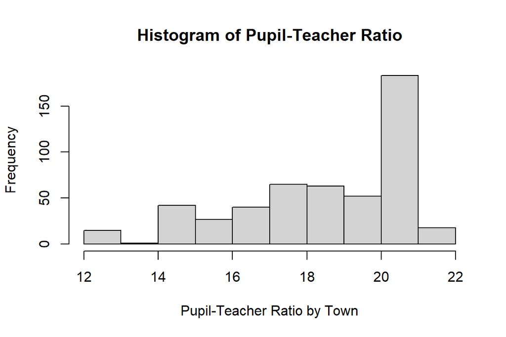

```r
# Histogram for pupil-teacher ratio by town
hist(Boston$ptratio, main="Histogram of Pupil-Teacher Ratio", xlab="Pupil-Teacher Ratio by Town")
```

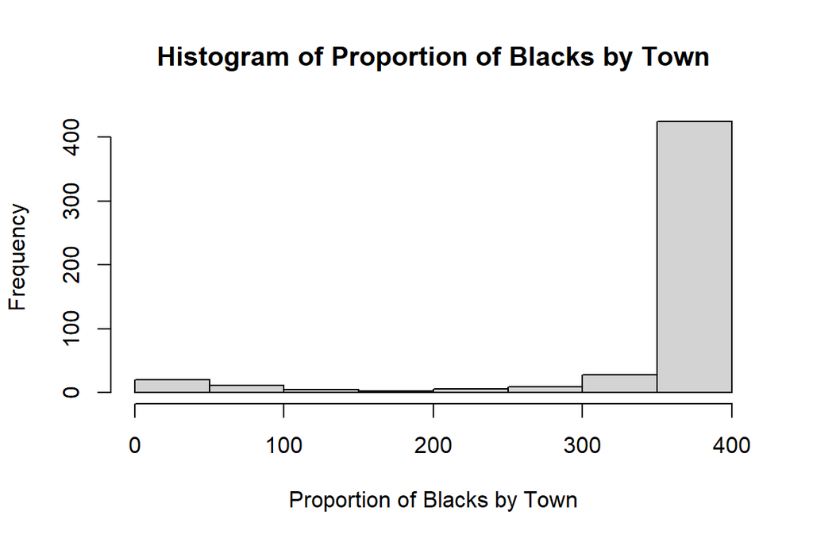

```r
# Histogram for the proportion of blacks by town
hist(Boston$black, main="Histogram of Proportion of Blacks by Town", xlab="Proportion of Blacks by Town")
```

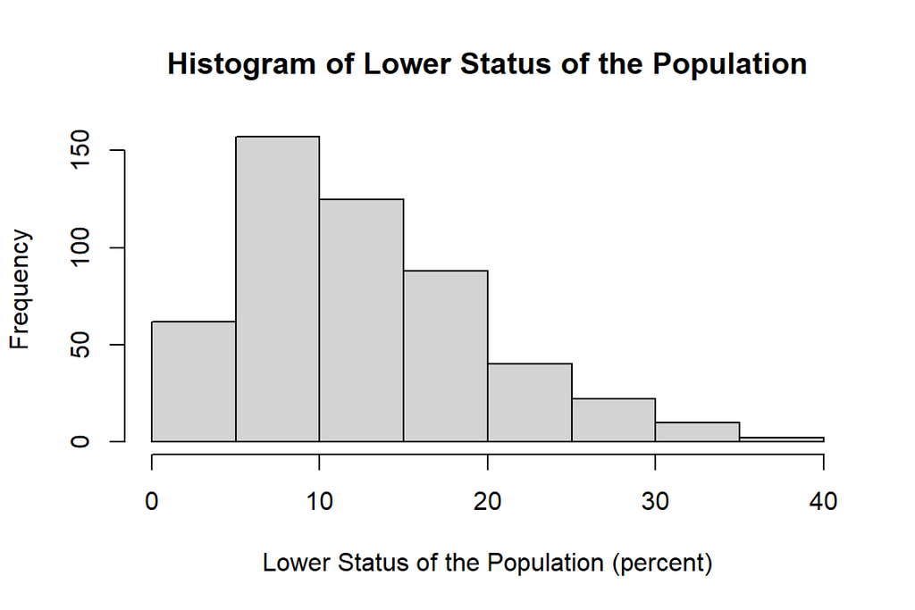

```r
# Histogram for lower status of the population
hist(Boston$lstat, main="Histogram of Lower Status of the Population", xlab="Lower Status of the Population (percent)")
```

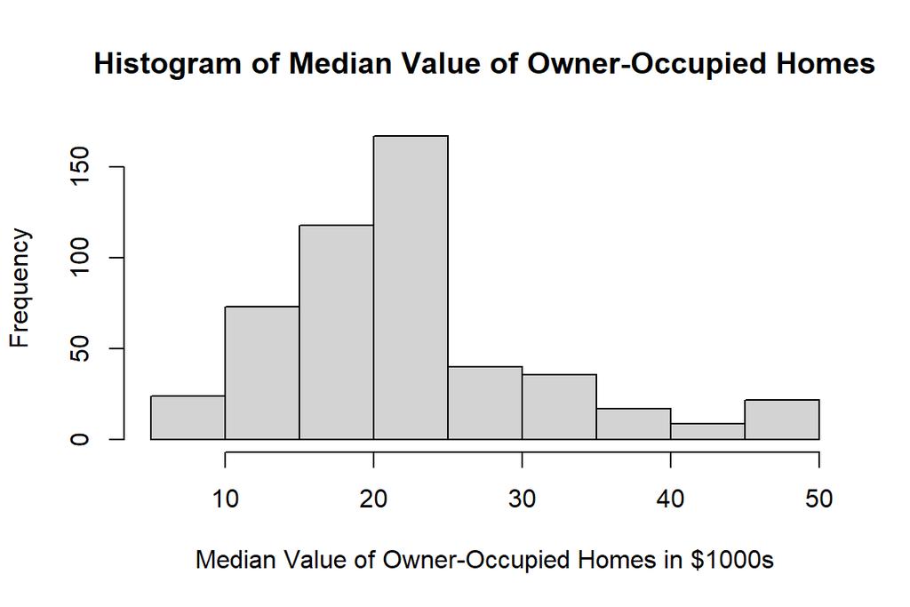

```r
# Histogram for median value of owner-occupied homes in $1000s
hist(Boston$medv, main="Histogram of Median Value of Owner-Occupied Homes", xlab="Median Value of Owner-Occupied Homes in $1000s")
```

It seems like crime rates, The proportion of residential land zoned and the proprtion of blacks in the population are variables that are distributed very unevenly. Let us analyze some correlations of the variables:

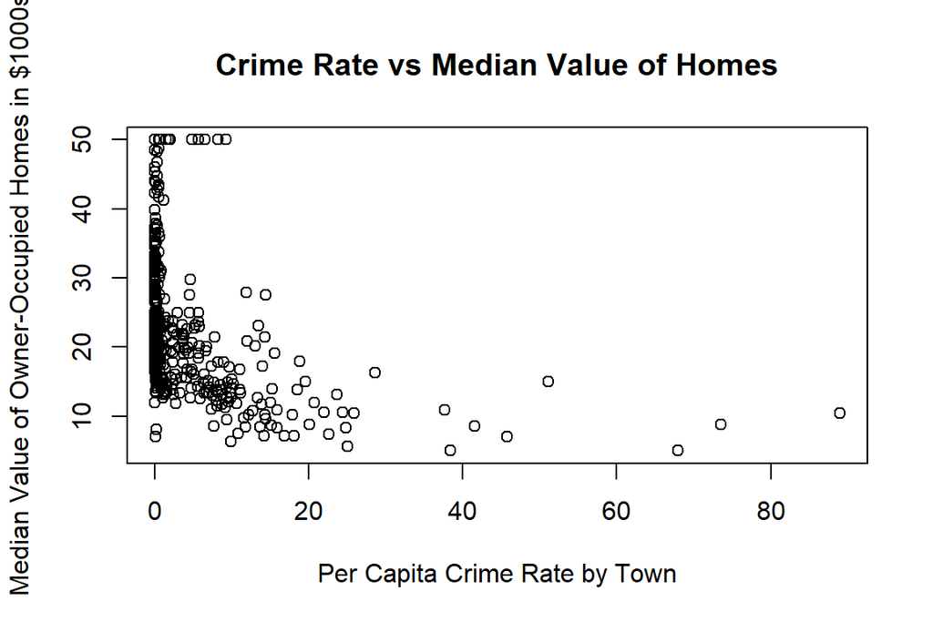

```r
plot(Boston$crim, Boston$medv, main="Crime Rate vs Median Value of Homes", xlab="Per Capita Crime Rate by Town", ylab="Median Value of Owner-Occupied Homes in $1000s")
```

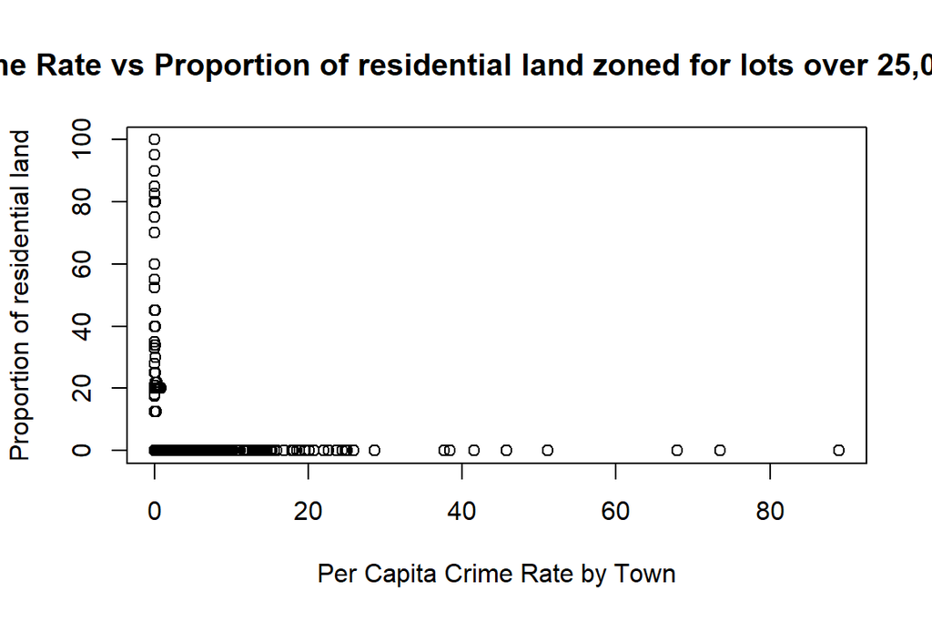

```r
plot(Boston$crim, Boston$zn, main="Crime Rate vs Proportion of residential land zoned for lots over 25,000 sq.ft.", xlab="Per Capita Crime Rate by Town", ylab="Proportion of residential land")
```

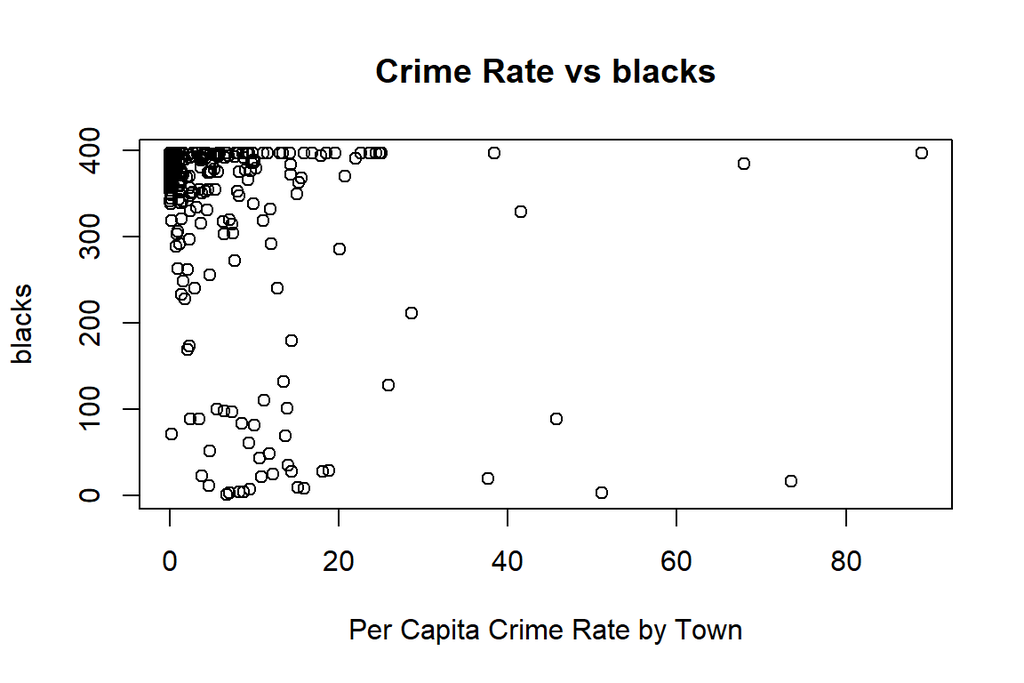

```r
plot(Boston$crim, Boston$black, main="Crime Rate vs blacks", xlab="Per Capita Crime Rate by Town", ylab="blacks")
```

By comparing a few different variables, we see that the low crime rate seems to correlate with the median value of homes and with the proportion of large residential plots. This is intuitive, as cheaper areas tend to have higher crime rate. In addition, a low proportion of large residential plots suggests that the area is more urban, which also intuitively correlates with a higher crime rates. The proportion of blacks in the population does not seem to have any correlation with the crime rates.